Skip to contents

# 🔬 Shocks, collapses, synchrony and fleets

Source: [`vignettes/articles/literature-analyses.Rmd`](https://github.com/Linbojun99/faofishingreport/blob/main/vignettes/articles/literature-analyses.Rmd)

📦 **Data**: [FAO Global Capture Production](https://www.fao.org/fishery/collection/capture/en), release **2026.1.0** (published by FAO on 2026-03-30; catches 1950–2024), downloaded from Capture_2026.1.0.zip. Licence [CC BY 4.0](https://creativecommons.org/licenses/by/4.0/). `fao_data_info()` shows the release you use and how to cite it.

The five functions of this article follow methods published in the fisheries and ecology literature. Each section gives the method with its sources, so that the results can be checked against the original studies, and says which settings are choices of this package rather than of those studies. The full references are at the end of the page.

- `catch_shocks()`, `collapse_analysis()` and `catch_synchrony()` take catch data, like the summary analyses: a fishing area from `fishing_area_data()`, or any subset of `load_fao_data()` (see 💾 FAO data).
- `distant_water_profile()` takes a country and follows its catch in all FAO areas.
- `compare_releases()` takes two releases of the FAO data.

The examples use the Northeast Atlantic (FAO area 27). The charts are saved in `figures/png/summary/` and the tables in `tables/`. The pelagic/demersal ratio, `pelagic_demersal()`, belongs to the same group of analyses and is described in 📈 Composition, stock status and trends.

```r
FAO27 <- fishing_area_data("Atlantic, Northeast")
```

The five functions share these arguments:

| Argument | Meaning | Default |
| --- | --- | --- |
| `plot` | Save the charts in `figures/png/summary/` | `TRUE` |
| `table` | Save the tables in `tables/` | `TRUE` |
| `lang` | Language of the charts and names: `"en"`, `"zh"` or `"both"`; `NULL` uses the language set with `fao_settings()` | `NULL` |
| `pptx` | Also save the charts as editable PowerPoint files in `figures/pptx/summary/` | `FALSE`, or `TRUE` after `fao_settings(pptx = TRUE)` |
| `plot_show` | Also draw each chart in the plot window (e.g. the Plots pane of RStudio) as it is saved | `FALSE`, or `plot_show` of `fao_settings()` |
| `label` | Name at the start of the file names | The fishing area (or the country) of the data |

They return their results invisibly: assign them (`x <- catch_shocks(...)`) to use the tables.

## 📝 In the Word report

`fao_report()` can add four of these analyses to the Word report of a fishing area (see 📝 Assessment report: Word, LaTeX and PDF). They are switched off by default:

```r
fao_report(27, shocks = TRUE, collapse = TRUE, synchrony = TRUE, distant = TRUE)
```

The settings of each function are given with the name of its section as prefix:

```r
fao_report(27, shocks = TRUE, collapse = TRUE, synchrony = TRUE, distant = TRUE,
           shocks_method = "gephart2017",   # catch_shocks(method = "gephart2017")
           collapse_method = "worm2006",    # collapse_analysis(method = "worm2006")
           collapse_seed = 2,               # seed of the random series of the null model
           synchrony_by = "country",        # catch_synchrony(by = "country")
           distant_countries = 5,           # profiles of the 5 main distant-water countries
           distant_min_catch = 100)         # distant_water_profile(min_catch = 100)
```

| Section | Function | Settings of the report only |
| --- | --- | --- |
| `shocks` | `catch_shocks()` |  |
| `collapse` | `collapse_analysis()` | `collapse_seed`: seed of the random series of the null model, default `1`, so that the report gives the same numbers every time |
| `synchrony` | `catch_synchrony()` |  |
| `distant` | `distant_water_profile()` | `distant_countries`: the number of countries profiled, default `3` (the countries with the largest distant-water catch in the area over the last five years), or their names, e.g. `c("China", "Japan")` |
| `pelagic` | `pelagic_demersal()` |  |

`compare_releases()` compares two versions of the data rather than describing a fishing area, so it is not a section of the report.

## ⚡ Catch shocks

A shock is a sudden, unusually large fall in production from one year to the next. Gephart et al. (2017) proposed a statistical method to find shocks in national fish production series, and Cottrell et al. (2019) used a version of it to compare shocks in crop, livestock, fisheries and aquaculture production. `catch_shocks()` applies both versions to FAO catch series and counts how often shocks happen, by year and by group.

### Method

By default a series is the catch of one country in one FAO area (`by = c("country", "area")`). It runs from its first year with catch to the last year of the data, with missing years counted as zero. In each series:

1. The catch $c_t$ is smoothed, and the residuals $r_t = c_t - \hat{c}_t$ from the smooth are kept.
2. The residuals are regressed on those of the year before: $r_t = a + b\,r_{t-1} + e_t$ (a lag-1 regression).
3. Years whose **Cook’s distance** in this regression is above a threshold are candidate shocks. Cook’s distance measures how much one observation changes the fitted regression, so it picks out years that break the usual year-to-year pattern.
4. A candidate is kept only if the catch fell below a **baseline** $B_t$ computed from the preceding years. The loss is $B_t - c_t$ tonnes, or $100\,(B_t - c_t)/B_t$ percent.
5. The shock has recovered in the first later year in which the catch is back to at least 95% of $B_t$.

The two methods differ in the smoother, the threshold and the baseline:

|  | `"cottrell2019"` (default) | `"gephart2017"` |
| --- | --- | --- |
| Smoother | LOESS, span 0.6 | lowess, span 2/3 |
| Cook’s distance above | 0.3 | 0.35 |
| Baseline $B_t$ | Median catch of the previous 7 years | Mean catch of the previous 5 years |
| Earliest possible shock | 8th year of the series | 6th year of the series |
| Source | Cottrell et al. (2019), Methods, and their [code](https://github.com/cottrellr/shocks) | Gephart et al. (2017), section 2, and their [code](https://github.com/jagephart/Shock_Detection) |

Two summaries follow from the shocks:

- the **shock frequency** of a year: the number of shocks divided by the number of series analysed in that year, in percent (Cottrell et al. 2019); a series counts from its first year with catch to the last year, also in years in which its catch fell to zero, so that a shock to zero is counted in both;
- the **shock rate** of a group (an area, a country, a continent or a species group): the number of shocks divided by the number of series in the group (Gephart et al. 2017).

Two settings are choices of this package. Series with catch in fewer than `min_years` years (20) are left out, because neither study gives a minimum length. The series of countries that no longer exist (e.g. the USSR) end in their last year with catch, so that the end of a country is not counted as a shock.

### Example

```r
shocks <- catch_shocks(FAO27$area_data)
```

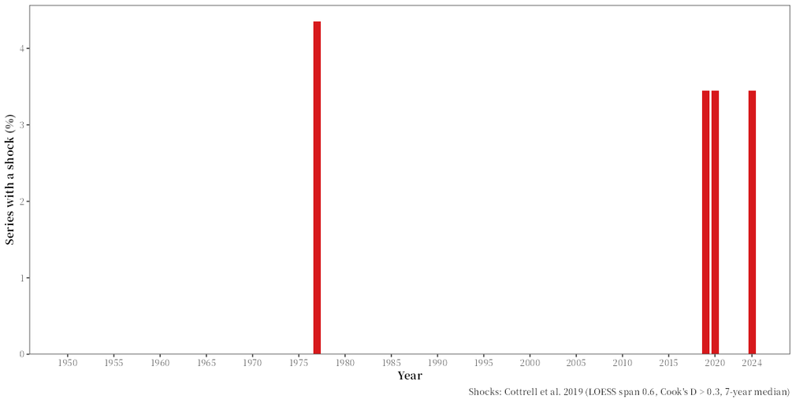

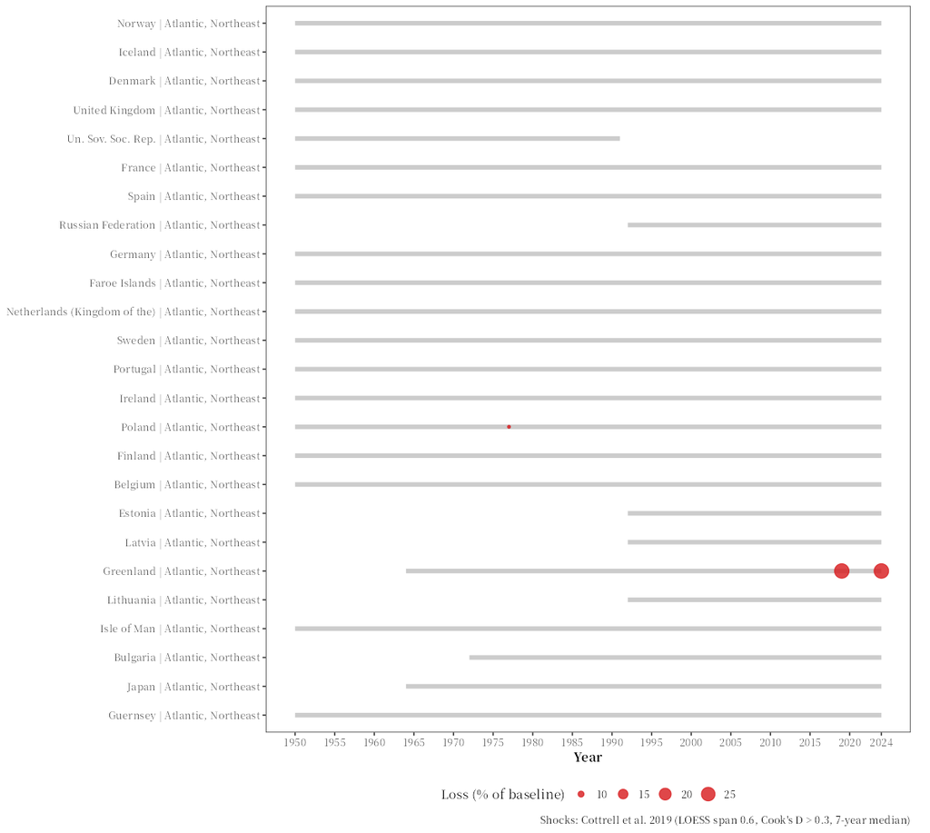

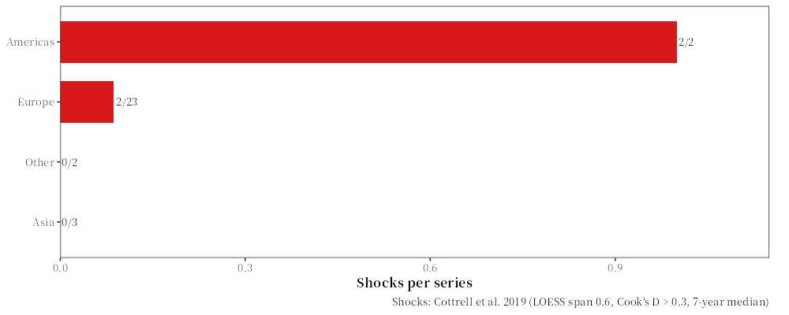

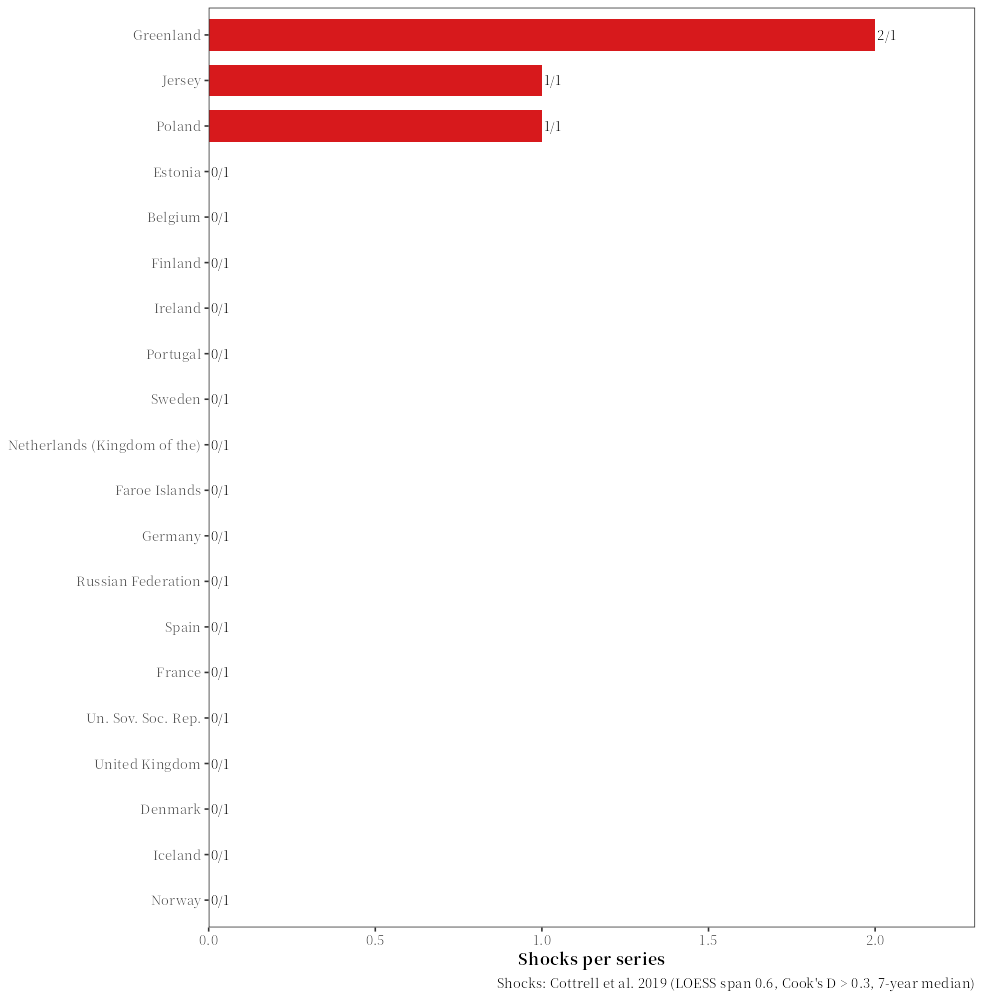

The first chart is the shock frequency of each year. The second shows the `top_n` series with the largest catch, from their first to their last year, with a dot for each shock sized by the loss in percent. The others give the shock rate of each continent and each country, with the number of shocks and series next to each bar; a grouping with a single group (here the area) has no chart.

The largest shocks, in tonnes:

```r
largest <- shocks$shocks[order(-shocks$shocks$loss_tonnes), ]
show_table(data.frame(largest[, c("series_name", "Year", "catch_tonnes", "baseline_tonnes", "loss_tonnes",
                                  "loss_pct", "cooks_distance", "recovery_years")], row.names = NULL),
           digits = c(0, 0, 0, 0, 0, 1, 2, 0))
```

| series_name | Year | catch_tonnes | baseline_tonnes | loss_tonnes | loss_pct | cooks_distance | recovery_years |
| --- | --- | --- | --- | --- | --- | --- | --- |
| Greenland \| Atlantic, Northeast | 2024 | 89,282 | 124,106 | 34,824 | 28.1 | 0.47 | NA |
| Greenland \| Atlantic, Northeast | 2019 | 85,189 | 118,128 | 32,939 | 27.9 | 0.32 | 3 |
| Poland \| Atlantic, Northeast | 1977 | 196,823 | 215,725 | 18,902 | 8.8 | 1.97 | 3 |
| Jersey \| Atlantic, Northeast | 2020 | 992 | 1,537 | 545 | 35.5 | 0.39 | NA |

The years with the highest shock frequency, and the shock rate by continent:

```r
show_table(data.frame(head(shocks$by_year[order(-shocks$by_year$shock_frequency_pct), ], 5), row.names = NULL))
```

| Year | n_series | n_shocks | shock_frequency_pct |
| --- | --- | --- | --- |
| 1977 | 23 | 1 | 4.35 |
| 2019 | 29 | 1 | 3.45 |
| 2020 | 29 | 1 | 3.45 |
| 2024 | 29 | 1 | 3.45 |
| 1950 | 18 | 0 | 0.00 |

```r
show_table(data.frame(subset(shocks$by_group, grouping == "continent"), row.names = NULL))
```

| grouping | group | group_name | n_series | n_shocks | shocks_per_series |
| --- | --- | --- | --- | --- | --- |
| continent | Americas | Americas | 2 | 2 | 1.00 |
| continent | Europe | Europe | 23 | 2 | 0.09 |
| continent | Asia | Asia | 3 | 0 | 0.00 |
| continent | Other | Other | 2 | 0 | 0.00 |

### Other settings

The method of Gephart et al. (2017). The file names do not include the method, so `label` keeps the charts of this call from replacing those of the first one:

```r
gephart <- catch_shocks(FAO27$area_data, method = "gephart2017", label = "FAO27 gephart2017")
```

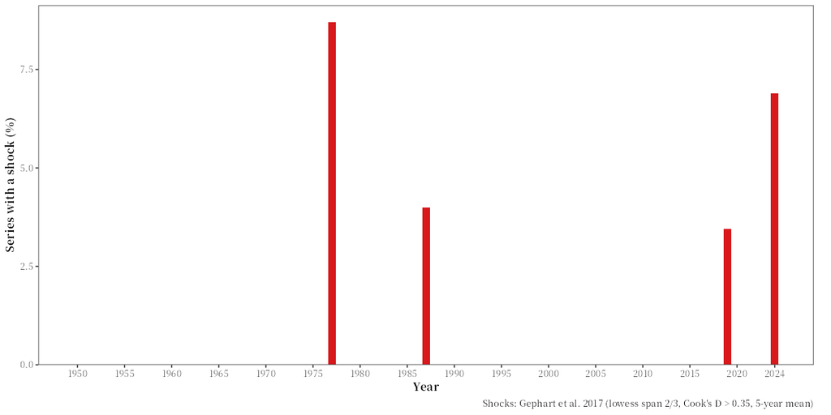

```r
both <- merge(shocks$shocks[, c("series", "Year")], gephart$shocks[, c("series", "Year")])
c(cottrell2019 = nrow(shocks$shocks), gephart2017 = nrow(gephart$shocks), both = nrow(both))
```

```
#> cottrell2019  gephart2017         both
#>            4            6            3
```

The two methods find 4 and 6 shocks, and only 3 of them in the same series and year: with a threshold close to the Cook’s distance of many years, the smoother and the baseline decide the borderline cases. Results that hold with both methods are the more robust.

With `by = "species"`, a series is the catch of one species item in the area, all countries together, and the shock rate is also given by ISSCAAP species group:

```r
species_shocks <- catch_shocks(FAO27$area_data, by = "species", label = "FAO27 species")
```

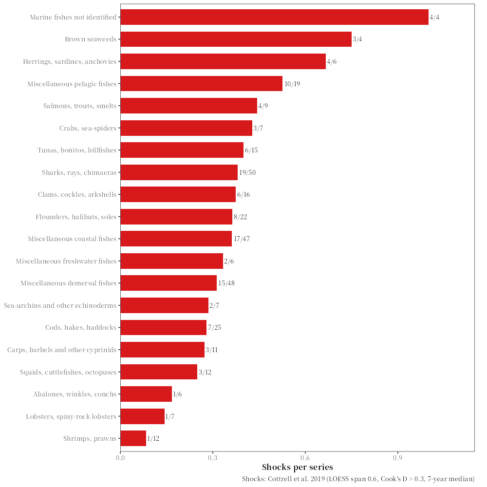

```r
groups <- subset(species_shocks$by_group, grouping == "species_group" & n_series >= 5)
show_table(data.frame(groups[, c("group_name", "n_series", "n_shocks", "shocks_per_series")], row.names = NULL))
```

| group_name | n_series | n_shocks | shocks_per_series |
| --- | --- | --- | --- |
| Herrings, sardines, anchovies | 6 | 4 | 0.67 |
| Miscellaneous pelagic fishes | 19 | 10 | 0.53 |
| Salmons, trouts, smelts | 9 | 4 | 0.44 |
| Crabs, sea-spiders | 7 | 3 | 0.43 |
| Tunas, bonitos, billfishes | 15 | 6 | 0.40 |
| Sharks, rays, chimaeras | 50 | 19 | 0.38 |
| Clams, cockles, arkshells | 16 | 6 | 0.38 |
| Flounders, halibuts, soles | 22 | 8 | 0.36 |
| Miscellaneous coastal fishes | 47 | 17 | 0.36 |
| Miscellaneous freshwater fishes | 6 | 2 | 0.33 |

The two studies analysed national totals, all species and areas of a country together. The same series come from the data of all areas with `by = "country"` (this takes longer):

```r
catch_shocks(load_fao_data(), by = "country", method = "gephart2017")
```

### Arguments and results

| Argument | Meaning | Default |
| --- | --- | --- |
| `area_data` | FAO catch data: `fishing_area_data()$area_data`, or any subset of `load_fao_data()` |  |
| `by` | What a series is: one or more of `"country"`, `"area"` and `"species"` | `c("country", "area")` |
| `method` | `"cottrell2019"` or `"gephart2017"` | `"cottrell2019"` |
| `min_years` | Series with catch in fewer years are left out | `20` |
| `top_n` | Number of series with the largest catch in the timeline chart | `25` |
| `plot`, `table`, `lang`, `pptx`, `label` | Common arguments (see the start of the page) |  |

| Element | Content |
| --- | --- |
| `shocks` | One row per shock: the series, `Year`, `catch_tonnes`, `baseline_tonnes`, `loss_tonnes`, `loss_pct`, `cooks_distance` and `recovery_years` |
| `by_year` | Each year: `n_series` (series analysed in that year, including those whose catch fell to zero), `n_shocks` and `shock_frequency_pct` |
| `by_group` | Shock rate by `grouping` (country, area, species, continent, species group): `n_series`, `n_shocks` and `shocks_per_series` |
| `series` | The series analysed: `first_year`, `last_year`, `n_years`, `total_tonnes` and `n_shocks` |

- Both studies analysed national totals. Series of one country in one area, or of one species, use the same method on smaller units.
- Highly variable series (e.g. Peruvian anchoveta) may show no shocks, because large changes are usual in them (Gephart et al. 2017).
- A shock is an anomaly of the catch series. It may come from the stock, the environment, markets, management or a change in reporting; the catch data do not say which.
- The smoother and the regression use the whole series, so a new year of data can change which earlier years are found as shocks.

## 💥 Fishery collapses

Two definitions of a collapse from catch data are widely used. Mullon et al. (2005) counted the collapses in FAO catch series and described the shape of the decline before them; Worm et al. (2006) followed the share of fisheries whose catch was below 10% of its maximum. Wilberg and Miller (2007) showed that the second measure also rises for random series with no trend, which is why `collapse_analysis()` compares the data with such random series.

### Method

[output not shown]

By default `exclude_countries` holds the countries that Mullon et al. (2005, p. 112) left out: the former USSR, Yugoslavia and Czechoslovakia, whose series end with the country; South Africa and Namibia, whose series were split; and China, whose series they considered distorted.

**Shape of the decline** (Mullon et al. 2005, p. 114), checked in this order (the paper does not give an order):

| Type | Rule |
| --- | --- |
| Plateau | Catch above $X_{max}/4$ in every year from $D_c - 8$ to $D_c - 3$: a sudden fall after a long period of high catch |
| Smooth | Correlation between catch and time from $D_c - 10$ to $D_c$ below $-0.7$: a long, regular decline |
| Erratic | Otherwise: a fall after several ups and downs |
| Not classified | Collapses less than 10 years after the first year of the series |

Mullon et al. found 366 collapses among 1,519 FAO series from 1950 to 2000 (24%): 21% plateau, 33% smooth and 45% erratic.

**Null model.** The maximum of a series grows with its length, so a share of “collapsed” fisheries defined against the maximum rises over time even when nothing changes (Wilberg and Miller 2007). With `null_model = TRUE` (default) the analysis is repeated on `n_sim` (100) sets of random series with no trend, with the same start years and lengths as the real series. As in Wilberg and Miller (2007), they are stationary first-order autoregressive lognormal series: $x_t = \rho\,x_{t-1} + \varepsilon_t$ with $\rho = 0.75$ and $\varepsilon_t \sim N\!\left(0,\ \sigma^2 (1 - \rho^2)\right)$, and catch $= e^{x_t}$, where $\sigma^2 = \ln(1 + \text{CV}^2)$ for a coefficient of variation of 80%. The share of collapses in these series is the level that the definition gives by itself.

**Random numbers.** The random series are drawn again at every run, so the results of the null model change slightly from one run to the next. `set.seed()` before the call fixes them. This page uses `set.seed(1)` so that the numbers in the text match the tables at every build of the site; `fao_report()` does the same with `collapse_seed` (default 1).

### Example

```r
set.seed(1)   # fixes the random series of the null model
collapses <- collapse_analysis(FAO27$area_data)
```

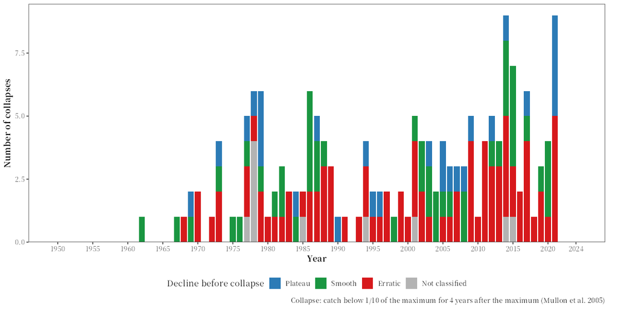

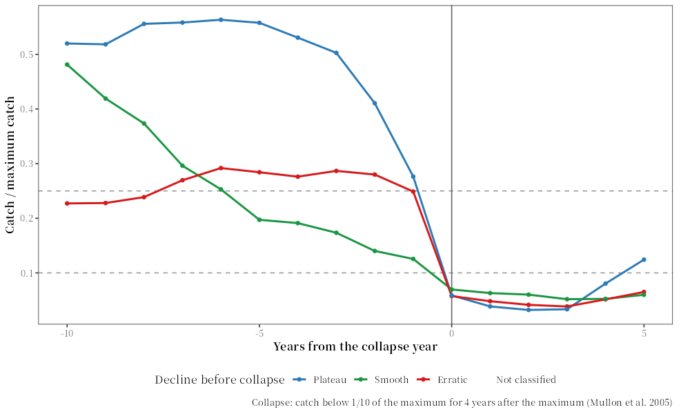

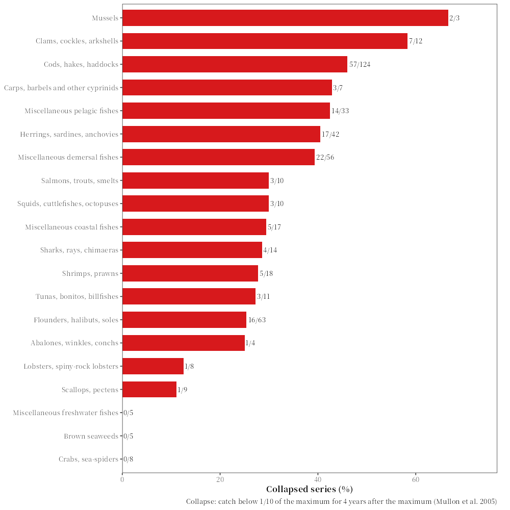

The first chart is the number of collapses in each year, by type of decline. The second is the mean catch of each type relative to its maximum, from 10 years before to 5 years after the collapse year; the dashed lines are $X_{max}/4$ and $X_{max}/10$. The third is the share of collapsed series in each ISSCAAP species group with at least 3 series.

```r
s <- collapses$summary
show_table(data.frame(s, row.names = NULL), digits = 1)
```

| type | n | pct_of_series | pct_of_collapses | n_series | null_pct_of_series |
| --- | --- | --- | --- | --- | --- |
| collapsed | 166 | 35.9 | 100.0 | 463 | 22.6 |
| plateau | 27 | 5.8 | 16.3 | 463 | NA |
| smooth | 45 | 9.7 | 27.1 | 463 | NA |
| erratic | 84 | 18.1 | 50.6 | 463 | NA |
| not classified | 10 | 2.2 | 6.0 | 463 | NA |

The largest series that collapsed, and the share of collapsed series by species group:

```r
collapsed <- subset(collapses$series, collapsed)
collapsed <- collapsed[order(-collapsed$max_tonnes), c("series_name", "max_year", "max_tonnes", "collapse_year", "type")]
show_table(data.frame(collapsed, row.names = NULL), digits = 0)
```

| series_name | max_year | max_tonnes | collapse_year | type |
| --- | --- | --- | --- | --- |
| Norway \| Capelin \| Atlantic, Northeast | 1977 | 2,115,701 | 1987 | plateau |
| Norway \| Atlantic herring \| Atlantic, Northeast | 1954 | 1,461,500 | 1973 | erratic |
| Norway \| Atlantic mackerel \| Atlantic, Northeast | 1967 | 868,600 | 1980 | erratic |
| Iceland \| Atlantic herring \| Atlantic, Northeast | 1966 | 770,700 | 1969 | plateau |
| Denmark \| Norway pout \| Atlantic, Northeast | 1974 | 475,142 | 2003 | smooth |
| United Kingdom \| Atlantic cod \| Atlantic, Northeast | 1956 | 474,900 | 2000 | erratic |
| Russian Federation \| Capelin \| Atlantic, Northeast | 1992 | 424,781 | 1994 | not classified |
| Denmark \| Haddock \| Atlantic, Northeast | 1969 | 317,500 | 1977 | erratic |
| Norway \| Norway pout \| Atlantic, Northeast | 1975 | 308,806 | 2001 | smooth |
| Denmark \| Atlantic cod \| Atlantic, Northeast | 1981 | 194,716 | 2017 | erratic |

```r
groups <- subset(collapses$by_group, grouping == "species_group" & n_series >= 3)
show_table(data.frame(groups[, c("group_name", "n_series", "n_collapsed", "pct_collapsed")], row.names = NULL), digits = 1)
```

| group_name | n_series | n_collapsed | pct_collapsed |
| --- | --- | --- | --- |
| Cods, hakes, haddocks | 124 | 57 | 46.0 |
| Flounders, halibuts, soles | 63 | 16 | 25.4 |
| Miscellaneous demersal fishes | 56 | 22 | 39.3 |
| Herrings, sardines, anchovies | 42 | 17 | 40.5 |
| Miscellaneous pelagic fishes | 33 | 14 | 42.4 |
| Shrimps, prawns | 18 | 5 | 27.8 |
| Miscellaneous coastal fishes | 17 | 5 | 29.4 |
| Sharks, rays, chimaeras | 14 | 4 | 28.6 |
| Clams, cockles, arkshells | 12 | 7 | 58.3 |
| Tunas, bonitos, billfishes | 11 | 3 | 27.3 |

**Reading the results.** In area 27, 166 of the 463 series (35.9%) collapsed by the definition of Mullon et al. (2005), against 22.6% in random series with no trend. The difference, not the share itself, is what points to real collapses. Of the collapses, 51% were erratic, 16% plateau and 27% smooth. Plateau collapses are the hardest to foresee: the catch stays high until it falls (Mullon et al. 2005).

### Other settings

The definition of Worm et al. (2006), with the same seed:

```r
set.seed(1)
worm <- collapse_analysis(FAO27$area_data, method = "worm2006")
```

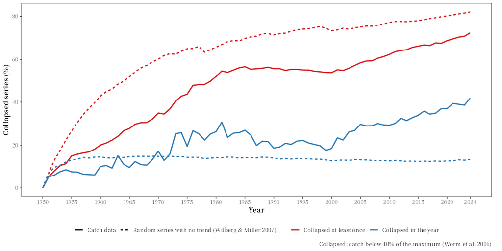

The solid lines are the data and the dashed lines the random series of the null model: in red the share of fisheries that have collapsed at least once, in blue the share collapsed in the year.

```r
show_table(data.frame(worm$summary, row.names = NULL), digits = 1)
```

| type | n | n_series | pct_of_series | null_pct_of_series |
| --- | --- | --- | --- | --- |
| collapsed in the last year | 103 | 246 | 41.9 | 13.3 |
| collapsed at least once | 178 | 246 | 72.4 | 82.1 |

```r
show_table(data.frame(subset(worm$by_year, Year %in% c(1960, 1980, 2000, max(Year))), row.names = NULL), digits = 1)
```

| Year | n_fisheries | n_collapsed | n_ever_collapsed | pct_current | pct_cumulative | null_pct_current | null_pct_cumulative |
| --- | --- | --- | --- | --- | --- | --- | --- |
| 1960 | 120 | 12 | 24 | 10.0 | 20.0 | 14.5 | 42.9 |
| 1980 | 175 | 46 | 91 | 26.3 | 52.0 | 14.2 | 65.6 |
| 2000 | 212 | 39 | 114 | 18.4 | 53.8 | 12.7 | 73.3 |
| 2024 | 246 | 103 | 178 | 41.9 | 72.4 | 13.3 | 82.1 |

By the last year, 72.4% of the fisheries of area 27 had collapsed at least once, but random series with no trend give 82.1%: in this area the rising cumulative share comes from the definition, which is the point made by Wilberg and Miller (2007). The share collapsed in the last year, 41.9% against 13.3% in the null model, is the better indicator.

Three more settings are often useful: `exclude_countries = character(0)` keeps all countries with the method of Mullon et al.; `null_model = FALSE` skips the random series, which is faster; `n_sim = 1000` gives a steadier null model.

### Arguments and results

| Argument | Meaning | Default |
| --- | --- | --- |
| `area_data` | FAO catch data: `fishing_area_data()$area_data`, or any subset of `load_fao_data()` |  |
| `method` | `"mullon2005"` or `"worm2006"` | `"mullon2005"` |
| `exclude_countries` | Countries left out with `"mullon2005"` | `c("Un. Sov. Soc. Rep.", "Yugoslavia SFR", "Czechoslovakia", "South Africa", "Namibia", "China")` |
| `complete_years` | With `"mullon2005"`, series need a record in each of the last this many years of the data | `20` |
| `min_mean_catch` | With `"mullon2005"`, minimum mean catch of a series (t a year) | `500` |
| `min_total_catch` | With `"worm2006"`, minimum total catch of a fishery (t) | `10000` |
| `null_model` | Repeat the analysis on random series with no trend (Wilberg and Miller 2007) | `TRUE` |
| `n_sim` | Number of random data sets of the null model | `100` |
| `plot`, `table`, `lang`, `pptx`, `label` | Common arguments (see the start of the page) |  |

[output not shown]

- Catch data alone cannot tell a collapse of the stock from a fall in catch caused by management, markets or reporting.
- A definition based on the maximum gives “collapses” in random series too. Compare the data with the null model, which is a reference level and not a statistical test.
- Worm et al. (2006) used species in large marine ecosystems from Sea Around Us data; here a fishery is a species item in an FAO area, so the shares are not directly comparable.
- With the default `exclude_countries`, the catch of China is left out, as by Mullon et al. (2005).

## 🎼 Synchrony and the portfolio effect

When the catches of different species rise and fall at different times, their total varies less than each of them. This is the portfolio effect, named after the way a diverse investment portfolio reduces risk. Ong et al. (2021) analysed 1,092 marine catch series and found that regions with more synchronous catches had less stable total catches. `catch_synchrony()` measures how synchronously the catch series of the data fluctuate, and how much their asynchrony stabilises the total catch.

### Method

The series are chosen as by Ong et al. (2021): the median catch is above `min_median` (10 t a year) and more than `min_nonzero` (3/4) of the years have catch. With `by = "species"`, only items identified to species are used (Ong et al. left out miscellaneous and “nei” items). Each series is **detrended** with a linear regression on year, as by Ong et al., since common trends make series look synchronous (Lepš et al. 2019); `detrend = "none"` keeps the trends.

With $\sigma_i$ the standard deviation of series $i$ (after detrending), $\sigma_T$ that of the total catch, $m_i$ the mean catch of series $i$ and $m_T$ the mean total catch:

| Measure | Formula | Column |
| --- | --- | --- |
| Synchrony | $\varphi = \sigma_T^2 / \left(\sum_i \sigma_i\right)^2$, from 0 (the fluctuations fully compensate each other) to 1 (perfectly synchronous) (Loreau and de Mazancourt 2008, eq. 9) | `synchrony_phi` |
| CV of the total | $\text{CV}_T = \sigma_T / m_T$ | `cv_total` |
| Weighted mean CV | $\sum_i \sigma_i / m_T$: the CV of the total if all series were perfectly synchronous | `weighted_mean_cv` |
| Decomposition | $\text{CV}_T = \sqrt{\varphi} \times \sum_i \sigma_i / m_T$ (Thibaut and Connolly 2013, eqs. 2–4): the lower the synchrony, the more stable the total |  |
| Mean CV of the series | $\overline{\text{CV}} = \frac{1}{n} \sum_i \sigma_i / m_i$ | `mean_cv_series` |
| Portfolio effect | $100 \times (\overline{\text{CV}} - \text{CV}_T) / \text{CV}_T$: how much more variable the single series are than their total, in percent (Ong et al. 2021, after Carlson and Satterthwaite 2011) | `portfolio_effect_pct` |
| Pairwise correlations | Correlations between the detrended series: their mean and the share that are positive | `mean_pairwise_correlation`, `positive_correlations_pct` |

The same measures are computed in moving windows of `window` years (20), with the linear trend removed in each window (a choice of this package), to show how synchrony changed over time. Ong et al. (2021) measured synchrony with wavelet coherence, which separates time scales; this function uses the simpler correlation-based measures above.

### Example

```r
sync <- catch_synchrony(FAO27$area_data)
```

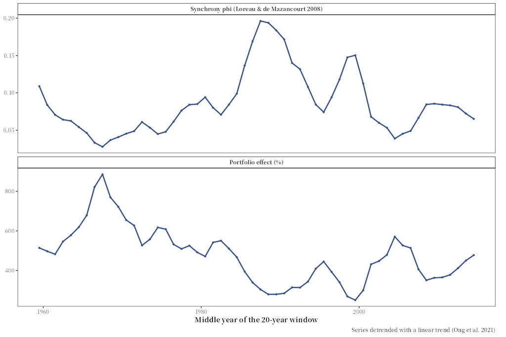

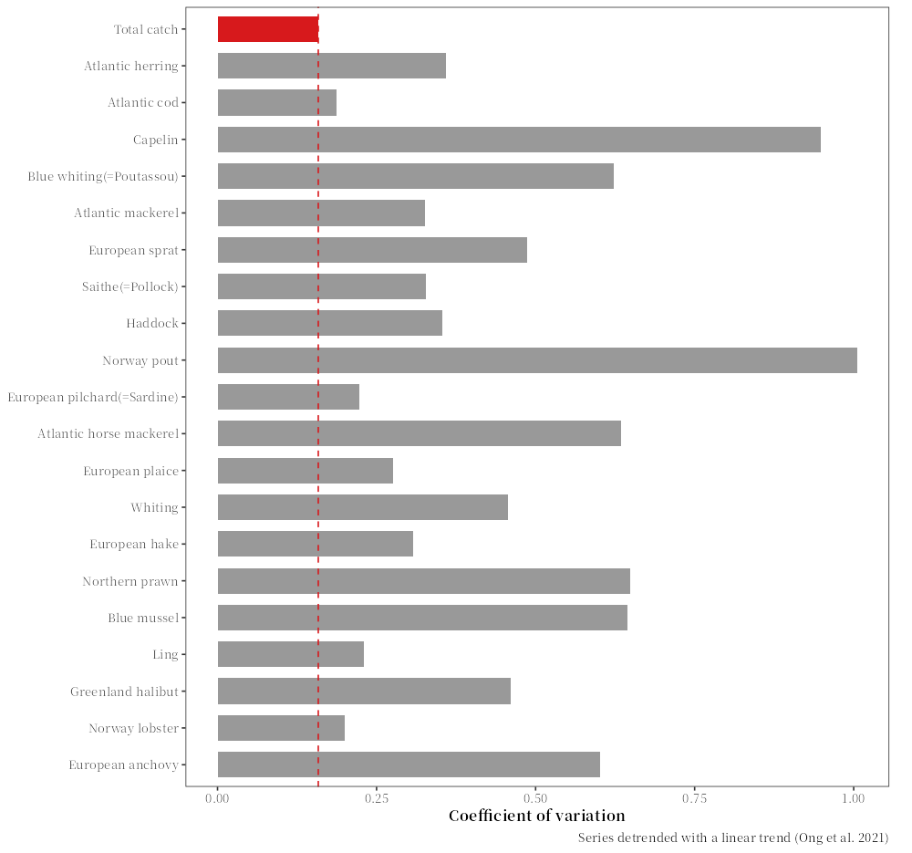

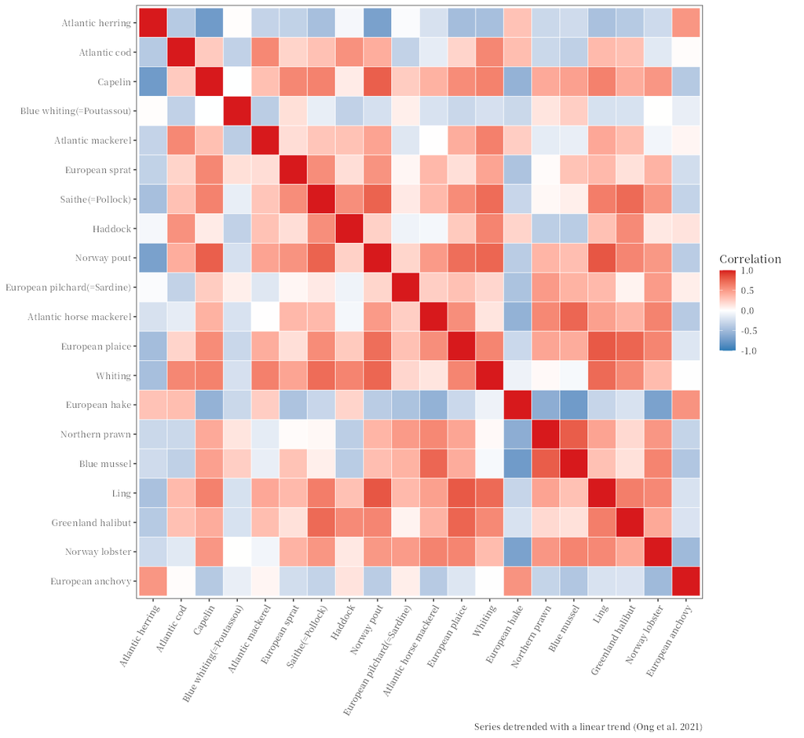

The first chart is the synchrony and the portfolio effect in each 20-year window, plotted at the middle year of the window. The second compares the CV of the total catch (red, dashed line) with the CV of the `top_n` largest series. The third shows the correlations between these series: red for series that rise and fall together, blue for series that compensate each other.

```r
show_table(sync$summary[, c("n_series", "synchrony_phi", "cv_total", "weighted_mean_cv", "mean_cv_series",
                            "portfolio_effect_pct", "mean_pairwise_correlation")], digits = 2)
```

| n_series | synchrony_phi | cv_total | weighted_mean_cv | mean_cv_series | portfolio_effect_pct | mean_pairwise_correlation |
| --- | --- | --- | --- | --- | --- | --- |
| 100 | 0.12 | 0.16 | 0.46 | 0.64 | 305.95 | 0.02 |

```r
with(sync$summary, c(cv_total = cv_total, decomposition = sqrt(synchrony_phi) * weighted_mean_cv))
```

```
#>      cv_total decomposition
#>     0.1583766     0.1583766
```

The second line checks the decomposition of Thibaut and Connolly (2013): the CV of the total is $\sqrt{\varphi}$ times the weighted mean CV. For each series, `variance_contribution_pct` is its contribution to the variance of the total catch, its covariance with the total divided by the variance of the total (the contributions add up to 100%, and a series that damps the total has a negative one); `sd_share_pct` is only its share of $\sum_i \sigma_i$, which ignores how the series vary together:

```r
show_table(sync$series[, c("series", "mean_tonnes", "sd_tonnes", "cv", "sd_share_pct", "variance_contribution_pct")], digits = 2)
```

| series | mean_tonnes | sd_tonnes | cv | sd_share_pct | variance_contribution_pct |
| --- | --- | --- | --- | --- | --- |
| Atlantic herring | 1,783,720.1 | 641,085.45 | 0.36 | 17.14 | -21.13 |
| Atlantic cod | 1,340,211.7 | 250,666.29 | 0.19 | 6.70 | 6.95 |
| Capelin | 963,394.1 | 913,315.70 | 0.95 | 24.42 | 58.50 |
| Blue whiting(=Poutassou) | 681,303.2 | 424,417.72 | 0.62 | 11.35 | 3.77 |
| Atlantic mackerel | 594,879.2 | 193,891.44 | 0.33 | 5.18 | 6.08 |
| European sprat | 379,887.1 | 184,815.48 | 0.49 | 4.94 | 10.46 |
| Saithe(=Pollock) | 369,793.0 | 121,278.75 | 0.33 | 3.24 | 6.85 |
| Haddock | 342,581.3 | 120,815.19 | 0.35 | 3.23 | 3.16 |
| Norway pout | 203,371.8 | 204,525.52 | 1.01 | 5.47 | 11.78 |
| European pilchard(=Sardine) | 160,844.9 | 35,782.65 | 0.22 | 0.96 | 0.66 |

```r
show_table(data.frame(subset(sync$windows, first_year %% 10 == 0), row.names = NULL), digits = 2)
```

| first_year | last_year | mid_year | n_series | synchrony_phi | cv_total | mean_cv_series | portfolio_effect_pct |
| --- | --- | --- | --- | --- | --- | --- | --- |
| 1950 | 1969 | 1959.5 | 100 | 0.11 | 0.08 | 0.49 | 514.30 |
| 1960 | 1979 | 1969.5 | 100 | 0.04 | 0.06 | 0.50 | 722.09 |
| 1970 | 1989 | 1979.5 | 100 | 0.09 | 0.08 | 0.47 | 491.84 |
| 1980 | 1999 | 1989.5 | 100 | 0.18 | 0.09 | 0.35 | 279.75 |
| 1990 | 2009 | 1999.5 | 100 | 0.15 | 0.09 | 0.33 | 250.20 |
| 2000 | 2019 | 2009.5 | 100 | 0.09 | 0.07 | 0.34 | 363.01 |

**Reading the results.** The 100 species series of area 27 have a synchrony of 0.12, far from 1: their fluctuations largely compensate each other. The CV of the total catch, 0.16, is 0.35 ($\sqrt{\varphi}$) times what it would be if all species fluctuated together (0.46). A single species series varies on average 4.1 times as much as the total, a portfolio effect of 306%. The mean correlation between two series is 0.02. In the moving windows, the synchrony was 0.11 in 1950–1969, reached 0.20 in 1978–1997 and fell to 0.07 in 2005–2024.

### Other settings

Without detrending, and by country instead of species:

```r
none <- catch_synchrony(FAO27$area_data, detrend = "none", label = "FAO27 no detrending")
```

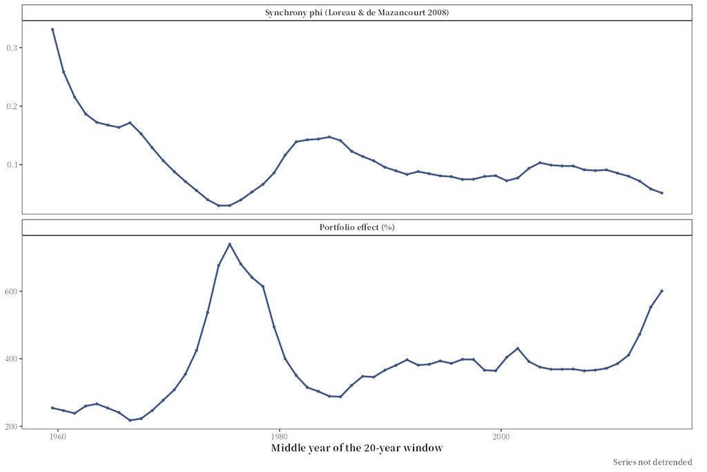

```r
countries <- catch_synchrony(FAO27$area_data, by = "country")
```

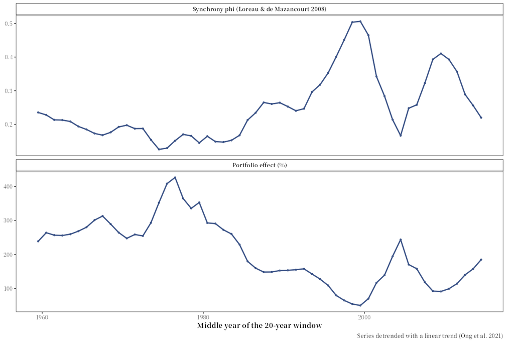

```r
settings <- rbind(sync$summary, none$summary, countries$summary)
settings$by <- c("species", "species", "country")
show_table(settings[, c("by", "detrend", "n_series", "synchrony_phi", "cv_total", "mean_cv_series",
                        "portfolio_effect_pct", "mean_pairwise_correlation")], digits = 2)
```

| by | detrend | n_series | synchrony_phi | cv_total | mean_cv_series | portfolio_effect_pct | mean_pairwise_correlation |
| --- | --- | --- | --- | --- | --- | --- | --- |
| species | linear | 100 | 0.12 | 0.16 | 0.64 | 305.95 | 0.02 |
| species | none | 100 | 0.09 | 0.16 | 0.78 | 378.89 | 0.02 |
| country | linear | 19 | 0.41 | 0.16 | 0.32 | 97.29 | 0.13 |

### Arguments and results

| Argument | Meaning | Default |
| --- | --- | --- |
| `area_data` | FAO catch data: `fishing_area_data()$area_data`, or any subset of `load_fao_data()` |  |
| `by` | What a series is: `"species"` or `"country"` | `"species"` |
| `detrend` | `"linear"` to remove a linear trend from each series, or `"none"` | `"linear"` |
| `window` | Length of the moving windows (years) | `20` |
| `top_n` | Number of series with the largest catch in the CV and correlation charts | `20` |
| `min_median` | Series need a median catch above this many tonnes a year | `10` |
| `min_nonzero` | Series need catch in more than this share of the years | `0.75` |
| `plot`, `table`, `lang`, `pptx`, `label` | Common arguments (see the start of the page) |  |

[output not shown]

- Trends make series look synchronous (Lepš et al. 2019): compare `detrend = "linear"` and `"none"` before reading much into the synchrony.
- The measures are correlation-based. Ong et al. (2021) used wavelet coherence, which separates time scales and allows for lags.
- Catches can fluctuate together because of the fish or because of fishing: Ong et al. (2021) found that coherent catches can come from coherent biomass or from coherent fishing mortality.
- The mean CV of the series is not weighted, so small and variable series raise the portfolio effect; $\varphi$ and the weighted mean CV weight each series by its size.

## 🚢 Distant-water profile of a country

Since 1950 marine fisheries have spread over a growing part of the ocean (Swartz et al. 2010). `distant_water_profile()` follows this expansion for one country with FAO statistics: its catch in the FAO areas it borders and in those it does not border, the number of areas in which it fishes each year, and the first and last year, peak and recent catch in each area.

### Method

- **Distant-water catch** is defined as by FAO: the catch of a country in the FAO major fishing areas it does not border. Fishing outside its own waters but in an area it borders does not count (Grainger and Garcia 1996, section 2.6; Garibaldi and Limongelli 2003, section 2.1).
- An area is **adjacent** to a country when the country’s land, including overseas territories, lies within 20 km of the FAO area boundary. This is a rule of this package, the same as in `coastal_distant()` (see 🔍 Data quality, diversity and fleets).
- An area counts as **fished** in a year when the country’s catch there is above `min_catch` tonnes (default 0, any reported catch).
- Inland fishing areas are left out.

FAO records the catch by the flag of the vessel and by FAO major area, not by exclusive economic zone (EEZ). The profile shows in which FAO areas a country’s fleet fished, not whether the catch came from its own waters, the waters of other countries or the high seas. Swartz et al. (2010) mapped the expansion with Sea Around Us catch maps; this function uses FAO statistics only, at the resolution of FAO major areas.

### Example

The function takes a country, as named in the FAO data, and uses the catch of all areas:

```r
china <- distant_water_profile("China")
```

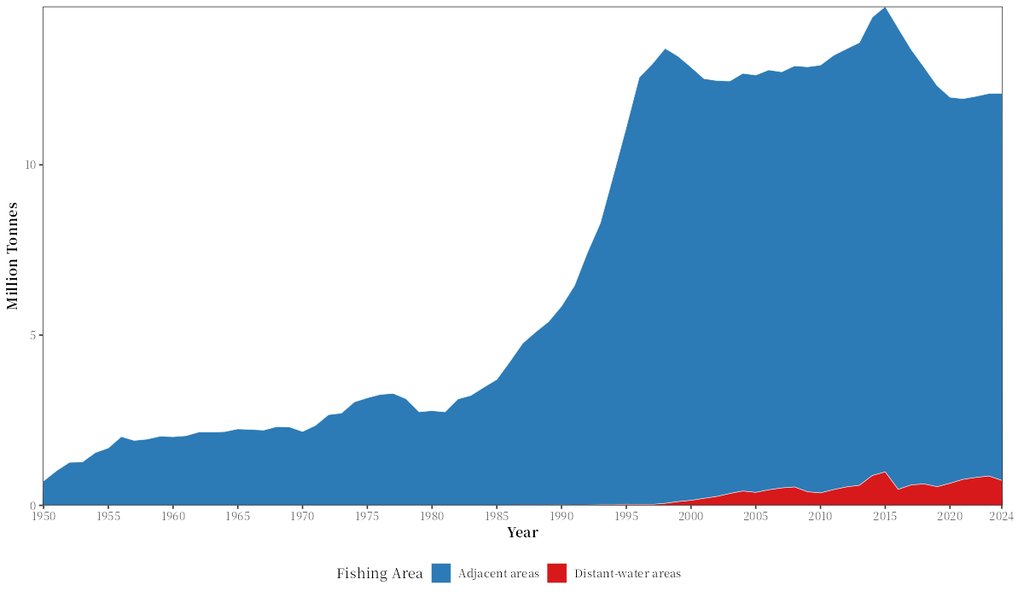

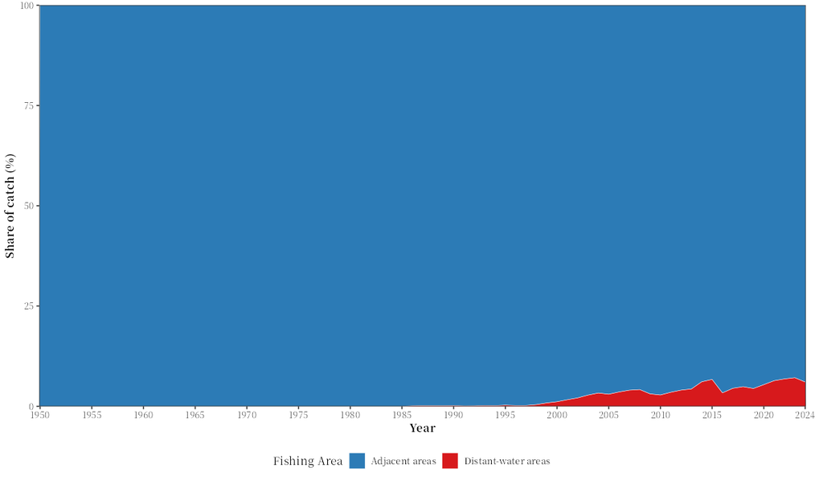

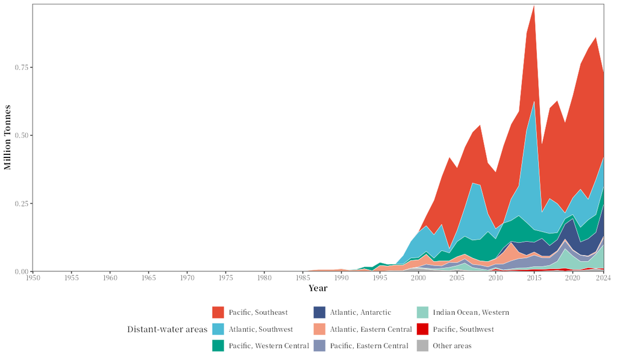

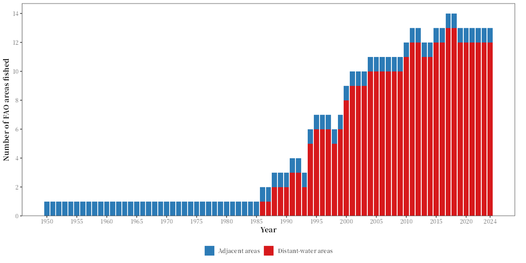

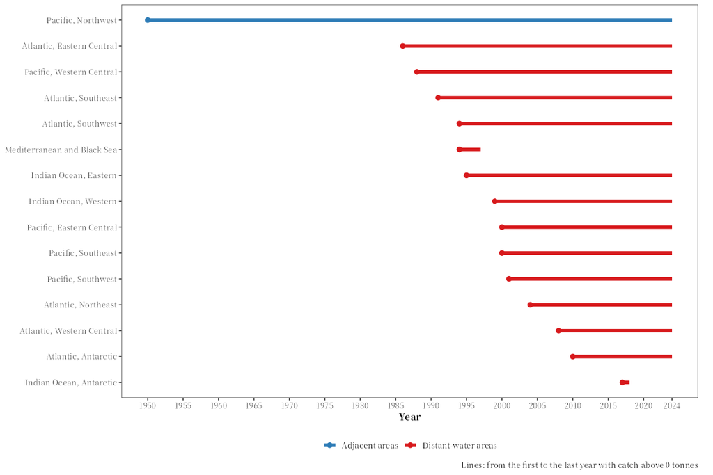

The charts are the catch in adjacent and distant-water areas (in tonnes and as a share), the catch in each distant-water area (the `top_n` largest, the others combined), the number of areas fished each year, and the years from the first to the last catch in each area.

```r
show_table(data.frame(tail(china$yearly, 5), row.names = NULL), digits = 1)
```

| Year | adjacent_tonnes | distant_tonnes | distant_pct | n_adjacent_areas | n_distant_areas | n_areas |
| --- | --- | --- | --- | --- | --- | --- |
| 2020 | 11,338,947 | 647,381.8 | 5.4 | 1 | 12 | 13 |
| 2021 | 11,180,662 | 762,963.3 | 6.4 | 1 | 12 | 13 |
| 2022 | 11,192,862 | 819,959.4 | 6.8 | 1 | 12 | 13 |
| 2023 | 11,232,509 | 862,450.3 | 7.1 | 1 | 12 | 13 |
| 2024 | 11,365,630 | 733,461.8 | 6.1 | 1 | 12 | 13 |

```r
show_table(china$areas[, c("area", "adjacent", "first_year", "last_year", "peak_year", "peak_tonnes",
                           "total_tonnes", "share_of_distant_pct")], n = 20, digits = 1)
```

| area | adjacent | first_year | last_year | peak_year | peak_tonnes | total_tonnes | share_of_distant_pct |
| --- | --- | --- | --- | --- | --- | --- | --- |
| Pacific, Northwest | TRUE | 1950 | 2024 | 2015 | 13,668,205.8 | 513,123,780.1 | NA |
| Pacific, Southeast | FALSE | 2000 | 2024 | 2022 | 554,788.4 | 7,017,268.6 | 50.4 |
| Atlantic, Southwest | FALSE | 1994 | 2024 | 2015 | 471,519.0 | 2,972,602.5 | 21.4 |
| Pacific, Western Central | FALSE | 1988 | 2024 | 2009 | 110,289.0 | 1,377,376.8 | 9.9 |
| Atlantic, Antarctic | FALSE | 2010 | 2024 | 2024 | 116,368.2 | 754,284.4 | 5.4 |
| Atlantic, Eastern Central | FALSE | 1986 | 2024 | 2012 | 67,402.0 | 576,779.9 | 4.1 |
| Pacific, Eastern Central | FALSE | 2000 | 2024 | 2015 | 42,492.0 | 517,196.8 | 3.7 |
| Indian Ocean, Western | FALSE | 1999 | 2024 | 2024 | 86,845.8 | 486,670.6 | 3.5 |
| Pacific, Southwest | FALSE | 2001 | 2024 | 2019 | 10,802.0 | 85,474.1 | 0.6 |
| Indian Ocean, Eastern | FALSE | 1995 | 2024 | 2023 | 6,451.9 | 66,412.3 | 0.5 |
| Atlantic, Southeast | FALSE | 1991 | 2024 | 2000 | 7,059.0 | 39,749.4 | 0.3 |
| Atlantic, Western Central | FALSE | 2008 | 2024 | 2023 | 1,872.0 | 7,402.1 | 0.1 |
| Atlantic, Northeast | FALSE | 2004 | 2024 | 2005 | 5,587.0 | 7,358.2 | 0.1 |
| Indian Ocean, Antarctic | FALSE | 2017 | 2018 | 2017 | 513.0 | 770.9 | 0.0 |
| Mediterranean and Black Sea | FALSE | 1994 | 1997 | 1995 | 137.0 | 376.0 | 0.0 |

`share_of_distant_pct` is the share of each distant-water area in all the distant-water catch of the country over the whole period. China borders only the Northwest Pacific (area 61). It reported its first catch in area 27 in 2004, and area 27 makes up 0.1% of its distant-water catch.

For China, FAO notes that in 2022 China reported 2.3 million tonnes of distant-water catch but gave species and areas only for the catch landed in China (area 61). FAO filled the other areas with data from regional fisheries management organizations and entered 1.3 million tonnes as “Marine fishes nei” in area 61 (FAO 2024). The recent distant-water catch of China is therefore partly counted in its adjacent area 61.

### Other settings

Spain, with `min_catch = 100`: an area counts as fished only in the years with more than 100 t:

```r
spain <- distant_water_profile("Spain", min_catch = 100)
```

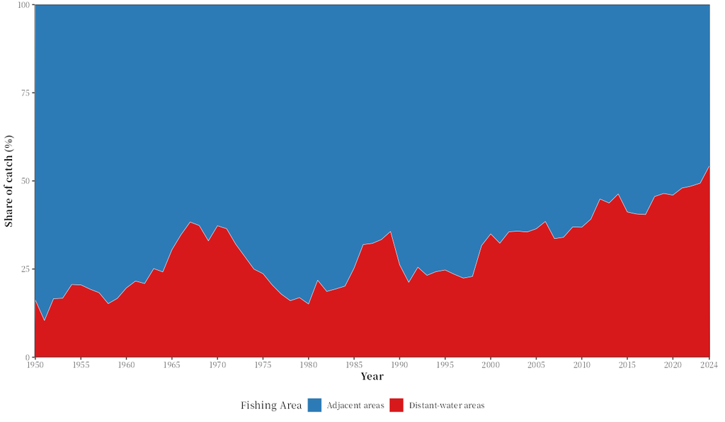

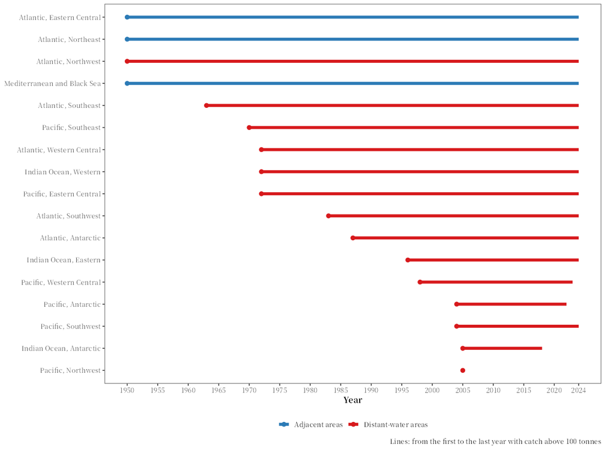

```r
show_table(spain$areas[, c("area", "adjacent", "first_year", "last_year", "peak_year", "peak_tonnes",
                           "total_tonnes", "share_of_distant_pct")], n = 20, digits = 1)
```

| area | adjacent | first_year | last_year | peak_year | peak_tonnes | total_tonnes | share_of_distant_pct |
| --- | --- | --- | --- | --- | --- | --- | --- |
| Atlantic, Northeast | TRUE | 1950 | 2024 | 1969 | 614,352.0 | 31,240,735.4 | NA |
| Atlantic, Eastern Central | TRUE | 1950 | 2024 | 1978 | 489,815.0 | 15,248,549.1 | NA |
| Mediterranean and Black Sea | TRUE | 1950 | 2024 | 1982 | 163,022.0 | 8,755,909.8 | NA |
| Atlantic, Northwest | FALSE | 1950 | 2024 | 1968 | 341,312.0 | 6,661,750.2 | 28.6 |
| Atlantic, Southeast | FALSE | 1963 | 2024 | 1970 | 246,000.0 | 5,457,179.9 | 23.4 |
| Indian Ocean, Western | FALSE | 1972 | 2024 | 2006 | 210,247.0 | 5,403,857.6 | 23.2 |
| Atlantic, Southwest | FALSE | 1983 | 2024 | 2014 | 197,658.0 | 3,844,766.4 | 16.5 |
| Pacific, Southeast | FALSE | 1970 | 2024 | 2000 | 28,933.0 | 605,979.2 | 2.6 |
| Pacific, Eastern Central | FALSE | 1972 | 2024 | 2024 | 66,924.0 | 581,127.0 | 2.5 |
| Pacific, Western Central | FALSE | 1998 | 2023 | 2013 | 45,035.0 | 418,408.1 | 1.8 |
| Atlantic, Western Central | FALSE | 1972 | 2024 | 2011 | 13,217.0 | 148,548.8 | 0.6 |
| Pacific, Southwest | FALSE | 2004 | 2024 | 2022 | 8,284.4 | 95,387.0 | 0.4 |
| Indian Ocean, Eastern | FALSE | 1996 | 2024 | 1998 | 13,379.0 | 50,818.3 | 0.2 |
| Atlantic, Antarctic | FALSE | 1987 | 2024 | 2003 | 882.0 | 9,504.2 | 0.0 |
| Pacific, Antarctic | FALSE | 2004 | 2022 | 2013 | 531.0 | 4,910.8 | 0.0 |
| Indian Ocean, Antarctic | FALSE | 2005 | 2018 | 2006 | 648.0 | 2,154.1 | 0.0 |
| Pacific, Northwest | FALSE | 2005 | 2005 | 2005 | 537.0 | 537.0 | 0.0 |
| Pacific, Northeast | FALSE | NA | NA | 2013 | 18.0 | 18.0 | 0.0 |

Spain borders three FAO areas: the Northeast Atlantic, the Mediterranean and Black Sea, and the Eastern Central Atlantic, because of the Canary Islands. Its catch in area 27 is therefore not distant-water catch, and `share_of_distant_pct` is empty for it.

How much of the distant-water catch of several countries comes from area 27, over the whole period (`share_of_distant_pct`) and over the last five years (`recent_share_pct`), with the distant-water share of their marine catch in the last year (`distant_pct_latest`):

```r
others <- c("Japan", "Bulgaria", "Romania", "Korea, Republic of")
profiles <- c(list(China = china, Spain = spain),
              sapply(others, distant_water_profile, plot = FALSE, table = FALSE, simplify = FALSE))
area27 <- do.call(rbind, lapply(names(profiles), function(country) {
  areas <- profiles[[country]]$areas
  here <- areas$area_en == "Atlantic, Northeast"
  recent <- 100 * areas$last_5_years_tonnes / sum(areas$last_5_years_tonnes[!areas$adjacent])
  data.frame(country = fao_translate(country, "country", lang = NULL),
             distant_pct_latest = tail(profiles[[country]]$yearly$distant_pct, 1),
             area27_adjacent = areas$adjacent[here],
             area27_first_year = areas$first_year[here],
             share_of_distant_pct = areas$share_of_distant_pct[here],
             recent_share_pct = ifelse(areas$adjacent[here], NA, recent[here]))
}))
show_table(area27, digits = 1)
```

| country | distant_pct_latest | area27_adjacent | area27_first_year | share_of_distant_pct | recent_share_pct |
| --- | --- | --- | --- | --- | --- |
| China | 6.1 | FALSE | 2004 | 0.1 | 0.0 |
| Spain | 54.2 | TRUE | 1950 | NA | NA |
| Japan | 7.6 | FALSE | 1964 | 0.3 | 1.5 |
| Bulgaria | 0.0 | FALSE | 1972 | 10.4 | NaN |
| Romania | 0.0 | FALSE | 1970 | 3.1 | NaN |
| Korea, Republic of | 34.9 | FALSE | 1983 | 0.0 | 0.1 |

### Arguments and results

| Argument | Meaning | Default |
| --- | --- | --- |
| `country_name` | The country, as named in the FAO data (e.g. `"China"`, `"Spain"`) |  |
| `top_n` | Number of distant-water areas shown separately; the others are combined | `8` |
| `min_catch` | An area counts as fished in a year when the country’s catch there is above this many tonnes | `0` |
| `data_version` | The FAO data release to use; see `load_fao_data()` | `"latest"` |
| `plot`, `table`, `lang`, `pptx`, `label` | Common arguments (see the start of the page); `label` defaults to the country |  |

[output not shown]

## 🔁 Revisions between FAO releases

FAO publishes a new release of the Global Capture Production data every year. A release adds the latest year and also revises earlier years when countries send corrected or more complete data (Garibaldi 2012). Zeller and Pauly (2018) call “presentist bias” the practice of applying improvements in reporting to recent years only, without revising the earlier years, which makes a time series show an increase that did not happen. `compare_releases()` compares two releases record by record and shows which years and countries were revised, and how far back the revisions reach.

### Method

A record is the catch of one country, species item and FAO area in one year. Each record of the two releases is put in one class:

| Class | Rule |
| --- | --- |
| `revised` | In both releases, with catches that differ by more than `tolerance` (0.5 t, rounding) |
| `added` | Only in the new release, for a year the older release already covered |
| `removed` | Only in the older release |
| `reclassified` | Removed under one species item and added under another with the same country, area, year and catch, e.g. when FAO renames or splits a species item; not counted as a revision |
| `new year` | In a year after the last year of the older release |
| `unchanged` | Everything else |

The function then sums the catch of each year in both releases and the revisions by country, and counts the records whose status flag changed (e.g. from an estimate to an official figure). The releases are compared on the names used by the package, matched through the FAO codes when a release is downloaded. No published study has compared successive FishStat releases record by record in this way: the comparison is a tool of this package, and the two papers above give the background.

### Example

The comparison needs both releases on the computer. The newest release is bundled with the package; download older ones with `download_fao_data()` (about 5 MB each, from FAO). `check_fao_update()` lists the releases available.

```r
check_fao_update()               # releases available from FAO
download_fao_data("2025.1.0")    # download an older release
```

```r
releases <- compare_releases("2025.1.0", "2026.1.0", area_name = "Atlantic, Northeast")
```

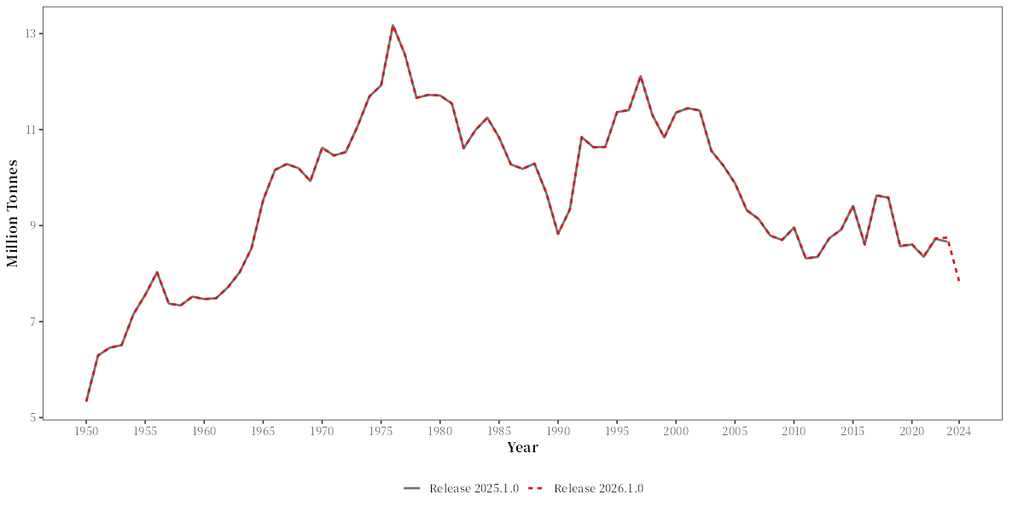

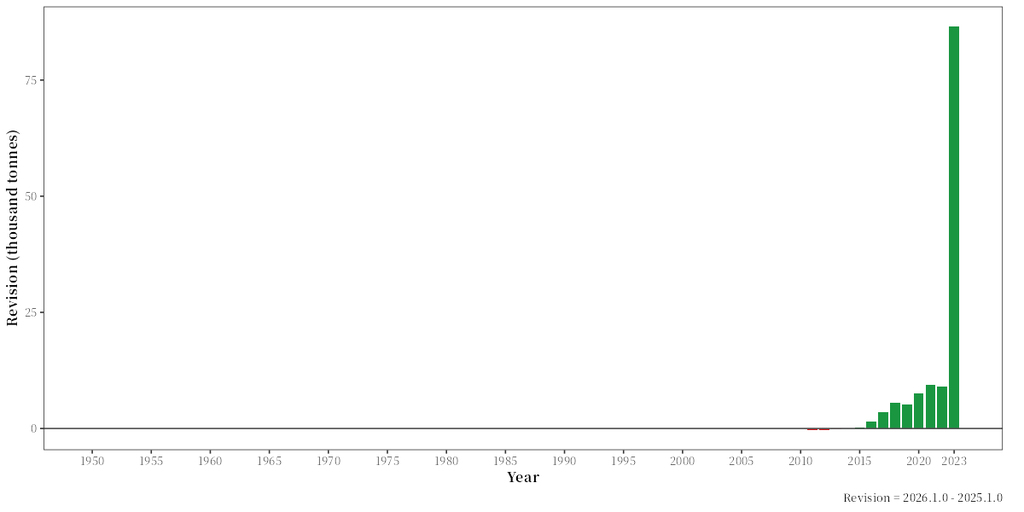

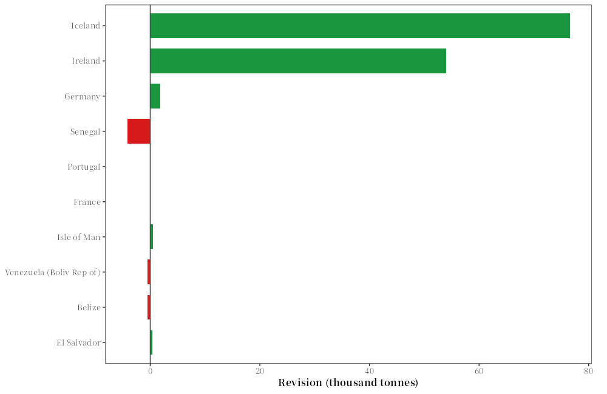

The first chart is the total catch of each year in the two releases. The second is the revision of each year’s total (new minus old release), in thousand tonnes. The third gives the net revision of the `top_n` countries with the largest revisions, ranked by the sum of their absolute revisions: a country can rank high with a small net revision when its revisions up and down cancel out.

```r
table(releases$records$change)
```

```
#>
#>        added reclassified      removed      revised
#>            9          136           35           53
```

```r
show_table(data.frame(tail(releases$by_year, 10), row.names = NULL), digits = 1)
```

| Year | old_tonnes | new_tonnes | change_tonnes | change_pct | n_revised | n_added | n_removed | n_reclassified | n_status_changed |
| --- | --- | --- | --- | --- | --- | --- | --- | --- | --- |
| 2014 | 8,914,935 | 8,914,898 | -36.6 | 0.0 | 0 | 0 | 1 | 6 | 0 |
| 2015 | 9,410,087 | 9,410,278 | 191.3 | 0.0 | 1 | 0 | 1 | 6 | 0 |
| 2016 | 8,605,840 | 8,607,412 | 1,572.4 | 0.0 | 3 | 1 | 1 | 8 | 0 |
| 2017 | 9,625,087 | 9,628,636 | 3,549.4 | 0.0 | 6 | 0 | 2 | 8 | 0 |
| 2018 | 9,581,025 | 9,586,641 | 5,615.3 | 0.1 | 4 | 0 | 3 | 6 | 0 |
| 2019 | 8,570,117 | 8,575,264 | 5,147.1 | 0.1 | 4 | 1 | 2 | 8 | 0 |
| 2020 | 8,604,066 | 8,611,702 | 7,635.2 | 0.1 | 3 | 1 | 2 | 12 | 0 |
| 2021 | 8,349,327 | 8,358,726 | 9,398.2 | 0.1 | 7 | 3 | 2 | 4 | 0 |
| 2022 | 8,722,573 | 8,731,646 | 9,073.2 | 0.1 | 4 | 0 | 3 | 8 | 0 |
| 2023 | 8,663,332 | 8,749,829 | 86,497.2 | 1.0 | 16 | 2 | 4 | 8 | 29 |

```r
show_table(releases$by_country[, c("country", "net_change_tonnes", "abs_change_tonnes", "n_records",
                                   "first_year", "last_year")], digits = 0)
```

| country | net_change_tonnes | abs_change_tonnes | n_records | first_year | last_year |
| --- | --- | --- | --- | --- | --- |
| Iceland | 76,551 | 76,551 | 1 | 2023 | 2023 |
| Ireland | 54,000 | 54,000 | 8 | 2016 | 2023 |
| Germany | 1,844 | 5,168 | 5 | 2021 | 2022 |
| Senegal | -4,189 | 4,465 | 20 | 2011 | 2023 |
| Portugal | 0 | 3,410 | 10 | 2007 | 2011 |
| France | 0 | 1,999 | 12 | 2018 | 2023 |
| Isle of Man | 521 | 1,279 | 13 | 2023 | 2023 |
| Venezuela (Boliv Rep of) | -524 | 524 | 10 | 2011 | 2023 |
| Belize | -448 | 450 | 2 | 2016 | 2019 |
| El Salvador | 425 | 425 | 3 | 2015 | 2021 |

`records` keeps only the records that changed. The largest revisions:

```r
records <- releases$records[order(-abs(releases$records$difference)), ]
show_table(data.frame(records[, c("country_name", "species_name", "Year", "tonnes_old", "tonnes_new",
                                  "difference", "change", "status_old", "status_new")], row.names = NULL),
           digits = 0)
```

| country_name | species_name | Year | tonnes_old | tonnes_new | difference | change | status_old | status_new |
| --- | --- | --- | --- | --- | --- | --- | --- | --- |
| Iceland | Atlantic herring | 2023 | 109,769 | 186,320 | 76,551 | revised | actual | actual |
| Ireland | North Atlantic rockweed | 2022 | 28,000 | 38,000 | 10,000 | revised | estimate | estimate |
| Ireland | North Atlantic rockweed | 2023 | 28,000 | 38,000 | 10,000 | revised | estimate | estimate |
| Ireland | North Atlantic rockweed | 2020 | 28,000 | 36,000 | 8,000 | revised | estimate | estimate |
| Ireland | North Atlantic rockweed | 2021 | 28,000 | 36,000 | 8,000 | revised | estimate | estimate |
| Ireland | North Atlantic rockweed | 2018 | 28,000 | 34,000 | 6,000 | revised | estimate | estimate |
| Ireland | North Atlantic rockweed | 2019 | 28,000 | 34,000 | 6,000 | revised | estimate | estimate |
| Ireland | North Atlantic rockweed | 2017 | 28,000 | 32,000 | 4,000 | revised | estimate | estimate |
| Germany | Beaked redfish | 2021 | NA | 2,140 | 2,140 | added | NA | actual |
| Ireland | North Atlantic rockweed | 2016 | 28,000 | 30,000 | 2,000 | revised | estimate | estimate |

**Reading the results.** Between the two releases, 53 records of area 27 were revised, 9 added and 35 removed. Most of them concern the last ten years covered by the older release (48 of the revised records), and the largest revision is that of the last year: the total catch of 2023 went up by 86 thousand tonnes (1%). The 136 reclassified records are catches moved from one species item to another, which leave the totals unchanged.

### Other settings

One country, ignoring changes of 100 t or less:

```r
iceland <- compare_releases("2025.1.0", "2026.1.0", area_name = "Atlantic, Northeast",
                            country_name = "Iceland", tolerance = 100)
```

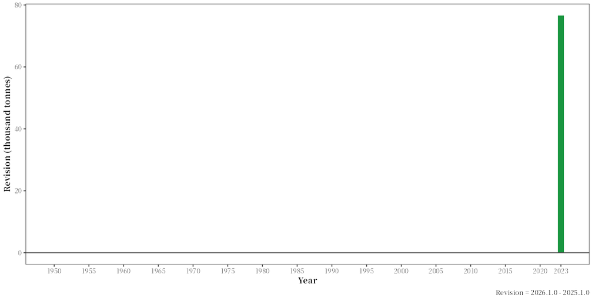

```r
revised <- subset(iceland$by_year, n_revised + n_added + n_removed > 0)
show_table(data.frame(revised[, c("Year", "old_tonnes", "new_tonnes", "change_tonnes", "change_pct",
                                  "n_revised", "n_added", "n_removed", "n_status_changed")], row.names = NULL),
           digits = 1)
```

| Year | old_tonnes | new_tonnes | change_tonnes | change_pct | n_revised | n_added | n_removed | n_status_changed |
| --- | --- | --- | --- | --- | --- | --- | --- | --- |
| 2023 | 1,371,088 | 1,447,639 | 76,551 | 5.6 | 1 | 0 | 0 | 0 |

For Iceland, only the catch of 2023 changed by more than 100 t, which raised its total by 5.6%. Without `area_name` and `country_name` the whole data set is compared; without `old` and `new` the newest release on the computer is compared with the one before it.

### Arguments and results

| Argument | Meaning | Default |
| --- | --- | --- |
| `old`, `new` | The releases to compare, e.g. `"2025.1.0"` and `"2026.1.0"`, or `"bundled"` for the data bundled with the package | `NULL`: the newest release on the computer for `new`, and the one before it for `old` |
| `area_name` | FAO fishing areas to compare | `NULL` (all) |
| `country_name` | Countries to compare | `NULL` (all) |
| `tolerance` | Changes of at most this many tonnes are ignored | `0.5` |
| `top_n` | Number of countries with the largest revisions in the country chart | `10` |
| `data_dir` | Folder where the downloaded releases are stored | `fao_data_dir()` |
| `plot`, `table`, `lang`, `pptx`, `label` | Common arguments (see the start of the page); `label` defaults to the areas and countries compared |  |

[output not shown]

- Recent years are revised most, because their figures are often provisional or estimated when first published (see `data_quality()` in 🔍 Data quality, diversity and fleets).
- A record counts as reclassified only when the same catch moves to another species item. When FAO splits one item into several with different catches, the change shows as records removed and added.
- Revisions show what FAO changed, not which release is right.

## 📖 References

Carlson, S.M. and Satterthwaite, W.H. (2011). Weakened portfolio effect in a collapsed salmon population complex. *Canadian Journal of Fisheries and Aquatic Sciences* 68: 1579–1589. [doi:10.1139/f2011-084](https://doi.org/10.1139/f2011-084)

Cottrell, R.S., Nash, K.L., Halpern, B.S., Remenyi, T.A., Corney, S.P., Fleming, A., Fulton, E.A., Hornborg, S., Johne, A., Watson, R.A. and Blanchard, J.L. (2019). Food production shocks across land and sea. *Nature Sustainability* 2: 130–137. [doi:10.1038/s41893-018-0210-1](https://doi.org/10.1038/s41893-018-0210-1)

FAO (2024). *The State of World Fisheries and Aquaculture 2024. Blue Transformation in action*. Rome: FAO. [doi:10.4060/cd0683en](https://doi.org/10.4060/cd0683en)

Garibaldi, L. (2012). The FAO global capture production database: a six-decade effort to catch the trend. *Marine Policy* 36: 760–768. [doi:10.1016/j.marpol.2011.10.024](https://doi.org/10.1016/j.marpol.2011.10.024)

Garibaldi, L. and Limongelli, L. (2003). *Trends in oceanic captures and clustering of large marine ecosystems: two studies based on the FAO capture database*. FAO Fisheries Technical Paper 435. Rome: FAO. https://www.fao.org/4/y4449e/y4449e00.htm

Gephart, J.A., Deutsch, L., Pace, M.L., Troell, M. and Seekell, D.A. (2017). Shocks to fish production: identification, trends, and consequences. *Global Environmental Change* 42: 24–32. [doi:10.1016/j.gloenvcha.2016.11.003](https://doi.org/10.1016/j.gloenvcha.2016.11.003)

Grainger, R.J.R. and Garcia, S.M. (1996). *Chronicles of marine fishery landings (1950-1994): trend analysis and fisheries potential*. FAO Fisheries Technical Paper 359. Rome: FAO. https://www.fao.org/4/w3244e/w3244e00.htm

Lepš, J., Götzenberger, L., Valencia, E. and de Bello, F. (2019). Accounting for long-term directional trends on year-to-year synchrony in species fluctuations. *Ecography* 42: 1728–1741. [doi:10.1111/ecog.04528](https://doi.org/10.1111/ecog.04528)

Loreau, M. and de Mazancourt, C. (2008). Species synchrony and its drivers: neutral and nonneutral community dynamics in fluctuating environments. *The American Naturalist* 172: E48–E66. [doi:10.1086/589746](https://doi.org/10.1086/589746)

Mullon, C., Fréon, P. and Cury, P. (2005). The dynamics of collapse in world fisheries. *Fish and Fisheries* 6: 111–120. [doi:10.1111/j.1467-2979.2005.00181.x](https://doi.org/10.1111/j.1467-2979.2005.00181.x)

Ong, J.J.L., Walter, J.A., Jensen, O.P. and Pinsky, M.L. (2021). Global hotspots of coherent marine fishery catches. *Ecological Applications* 31: e02321. [doi:10.1002/eap.2321](https://doi.org/10.1002/eap.2321)

Swartz, W., Sala, E., Tracey, S., Watson, R. and Pauly, D. (2010). The spatial expansion and ecological footprint of fisheries (1950 to present). *PLoS ONE* 5: e15143. [doi:10.1371/journal.pone.0015143](https://doi.org/10.1371/journal.pone.0015143)

Thibaut, L.M. and Connolly, S.R. (2013). Understanding diversity–stability relationships: towards a unified model of portfolio effects. *Ecology Letters* 16: 140–150. [doi:10.1111/ele.12019](https://doi.org/10.1111/ele.12019)

Wilberg, M.J. and Miller, T.J. (2007). Comment on “Impacts of biodiversity loss on ocean ecosystem services”. *Science* 316: 1285. [doi:10.1126/science.1137946](https://doi.org/10.1126/science.1137946)

Worm, B., Barbier, E.B., Beaumont, N., Duffy, J.E., Folke, C., Halpern, B.S., Jackson, J.B.C., Lotze, H.K., Micheli, F., Palumbi, S.R., Sala, E., Selkoe, K.A., Stachowicz, J.J. and Watson, R. (2006). Impacts of biodiversity loss on ocean ecosystem services. *Science* 314: 787–790. [doi:10.1126/science.1132294](https://doi.org/10.1126/science.1132294)

Zeller, D. and Pauly, D. (2018). The ‘presentist bias’ in time-series data: implications for fisheries science and policy. *Marine Policy* 90: 14–19. [doi:10.1016/j.marpol.2018.01.015](https://doi.org/10.1016/j.marpol.2018.01.015)